# Homework 2

Şuheda Buse Erduran

2022-05-09

# Homework 2: Forecasting With Regression

The aim of this homework is understanding the characteristics of the data and then forecasting the Unleaded Gasoline Sale for the Quarters of 2007 with the help of time series regression methods. The data has 10 types of variables such as Price of Unleaded Gasoline (PU) and Price of Diesel Gasoline (PG) and Unleaded Gasoline Sale (UGS) at the beginning of the data. This data set consists of 8 years (2000-2007) and 32 Quarters accordingly. The task is to analyze the behavior of the UGS and put it in a linear regression model for forecasting UGS values of 2007.

The packages that are needed for this homework are implemented below:

```r
library(readxl)
library(lubridate)
library(zoo)
library(ggplot2)
library(RcppRoll)
library(GGally)
library(skimr)
library(forecast)
library(dplyr)
library(data.table)
```

## 1) Data Gathering and Manipulations

The excel file is read, Quarters are shown as date to R and column names are changed for an easy usage:

```r
data=read_xlsx("IE360_Spring22_HW2_data.xlsx",sheet=1, col_names=TRUE)
names(data)
```

```
##  [1] "Quarter"
##  [2] "Unleaded Gasoline Sale (UGS)"
##  [3] "RNUV"
##  [4] "# LPG Vehicles (NLPG)"
##  [5] "Price of Unleaded Gasoline (PU)"
##  [6] "Price of Diesel Gasoline (PG)"
##  [7] "# Unleaded Gasoline Vehicles (NUGV)"
##  [8] "# of Diesel Gasoline Vehicles (NDGV)"
##  [9] "GNP Agriculture"
## [10] "GNP Commerce"
## [11] "GNP Total"
```

```r
data$Quarter= as.Date(as.yearqtr(data$Quarter,format="%Y_Q%q"))

colnames(data)= c("Quarter","UGS","RNUV","NLPG","PU","PG","NUGV","NDGV","GNPA","GNPC","GNP")
```

The variables:

**UGS:** Unleaded gasoline sale for the given quarter

**RNUV:** An index that indicates the rate of new unleaded gasoline by using vehicles being added to the traffic in a quarter

**PU:** Average price (adjusted with an index) of a liter of unleaded gasoline for the given quarter

**PG:** Average price (adjusted with an index) of a liter of diesel gasoline for the given quarter

**NUGV:** Number of unleaded gasoline using vehicles in the traffic

**NDGV:** Number of diesel gasoline using vehicles in the traffic (per 1000 people)

**GNPA:** Agriculture component of Gross National Product (adjusted with an index)

**GNPC:** Commerce component of Gross National Product (adjusted with an index)

**GNP:** Grand total for GNP (agriculture, commerce and other components total).

## 2) Data Visualizations Before Regression

The UGS part of the data is plotted so that the data can be interpreted before any change on the data.

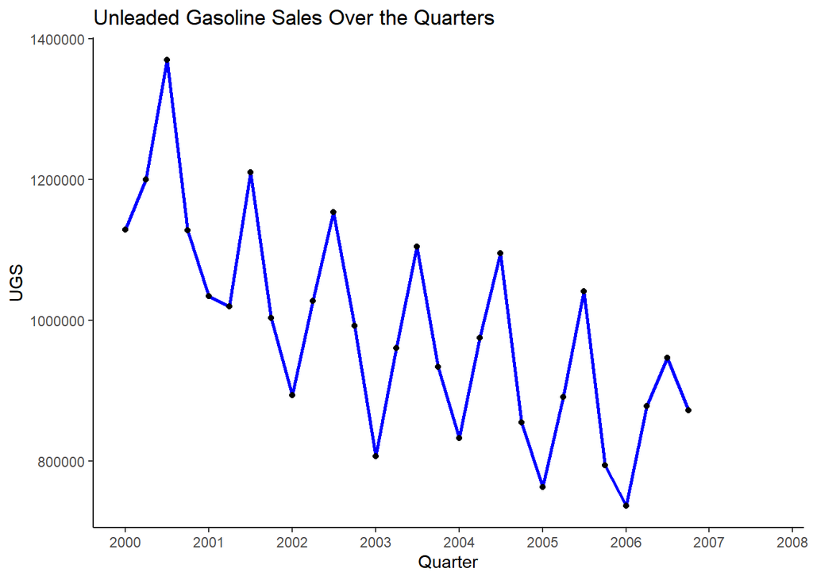

```r
ggplot(data, aes(x=Quarter,y=UGS))+
  geom_path(group=1,size=1,color='blue')+
  geom_point()+
  labs(title = "Unleaded Gasoline Sales Over the Quarters")+theme_classic()+scale_x_date(date_breaks = "1 year", date_labels = "%Y")
```

As can be seen at the plotted line, there is a declining behaviour in the data. It means that there is a declining trend on the Unleaded Gasoline Sales. Also, for every year, the third quarter has the biggest value and generally increase between the first and the second quarter. This can be a signal of seasonality on the data.

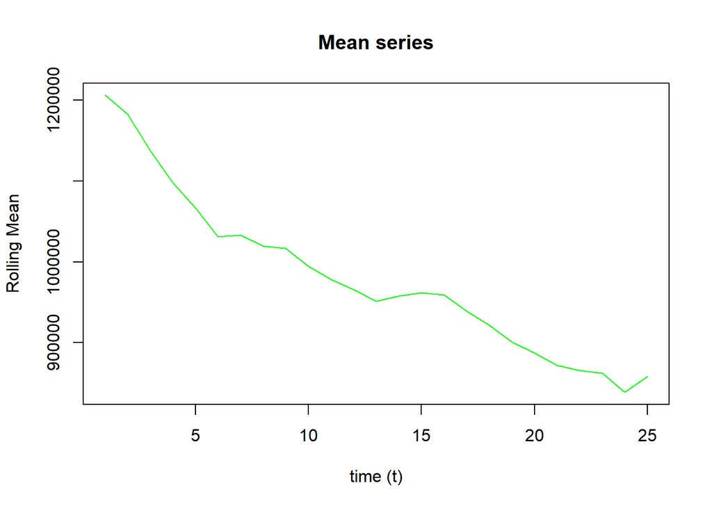

```r
data_mean=roll_mean(data$UGS[1:28],4,align='left')
data_var=roll_var(data$UGS[1:28],4,align='left')
plot(data_mean,
     type='l',col='green',
     xlab = "time (t)",
     ylab = "Rolling Mean",
     main = "Mean series")
```

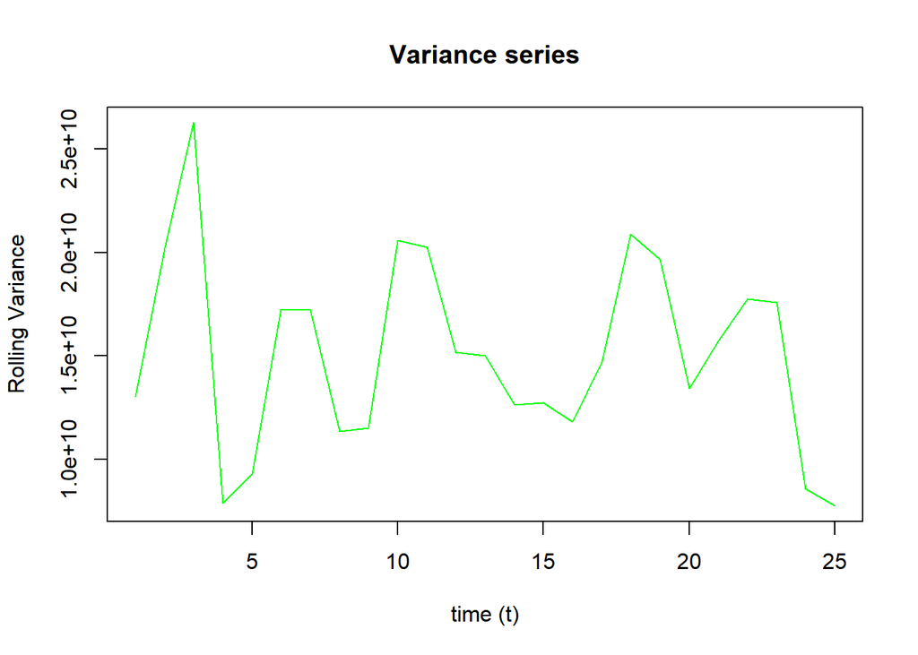

```r
plot(data_var,
     type='l',col='green',
     xlab = "time (t)",
     ylab = "Rolling Variance",
     main = "Variance series")
```

By looking at the rolling mean series of UGS, it can be said that the data is clearly not stationary, one can see the trending line by looking at that plot. However, there is no visible proof of non-stationarity with respect to variance. By seeing only the rolling variance series, non-stationarity cannot be observed.

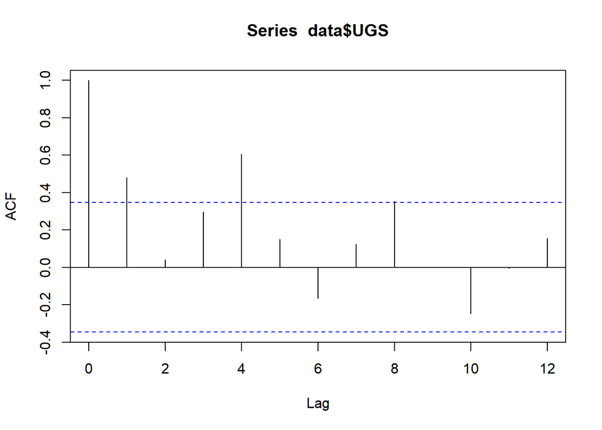

```r
acf(data$UGS,lag.max=12,na.action=na.pass)
```

This autocorrelation plot shows that there is high autocorrelation at lag 1, this means that there might be a trend in the data. Also, the high autocorrelation values at lags which are the multiples of 4 means that the idea of a seasonality is more possible now.

## 3) Model Building for Linear Regression

To understand the correlations between the variables at once in a single plotted table. the ggpairs function is used. This way, the variables which has the strongest correlations with UGS is seen. Also, The seasonality variable is added with the name ‘Q’.

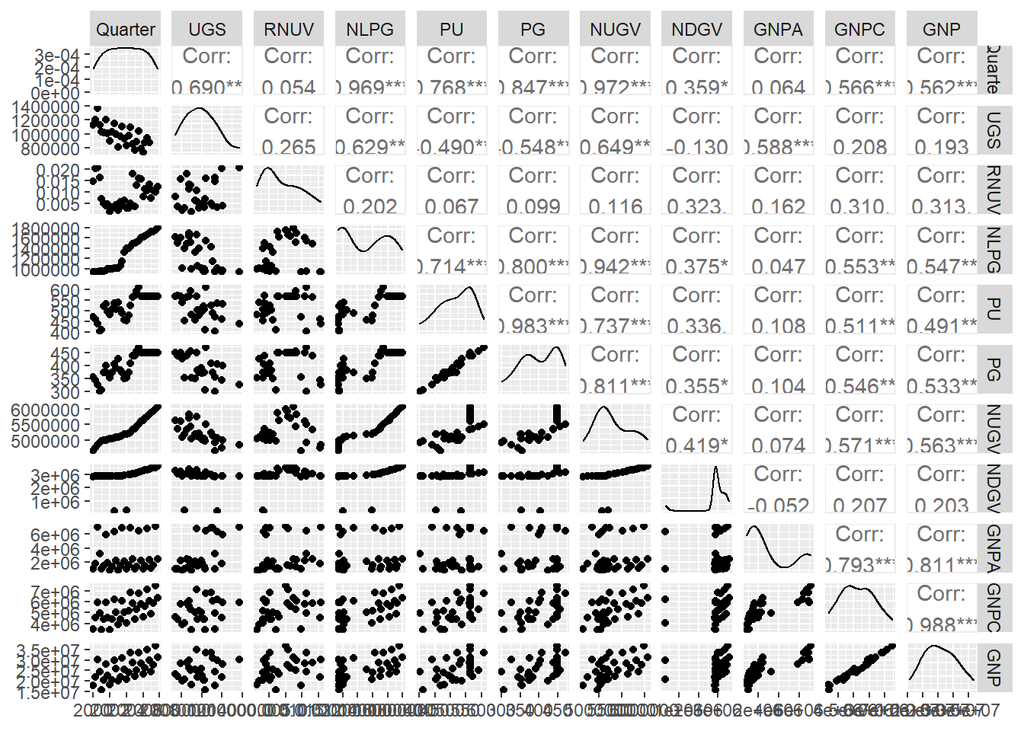

```r
ggpairs(data, cardinality_threshold=32)
```

```r
Q=seq(1,4,by=1)
data=cbind(data,Q)
modelseason =lm(UGS~Quarter+as.factor(Q),data=data)
summary(modelseason)
```

```
##
## Call:
## lm(formula = UGS ~ Quarter + as.factor(Q), data = data)
##
## Residuals:
##    Min     1Q Median     3Q    Max
## -81160 -31254  -3504  28684  94480
##
## Coefficients:
##                 Estimate Std. Error t value Pr(>|t|)
## (Intercept)   2666578.76  152583.51  17.476 8.95e-15 ***
## Quarter          -147.82      12.57 -11.762 3.29e-11 ***
## as.factor(Q)2  121380.99   25989.54   4.670 0.000106 ***
## as.factor(Q)3  273421.28   26064.52  10.490 3.08e-10 ***
## as.factor(Q)4   94953.53   26190.92   3.625 0.001419 **
## ---
## Signif. codes:  0 '***' 0.001 '**' 0.01 '*' 0.05 '.' 0.1 ' ' 1
##
## Residual standard error: 48580 on 23 degrees of freedom
##   (4 observations deleted due to missingness)
## Multiple R-squared:  0.9119, Adjusted R-squared:  0.8966
## F-statistic: 59.51 on 4 and 23 DF,  p-value: 8.468e-12
```

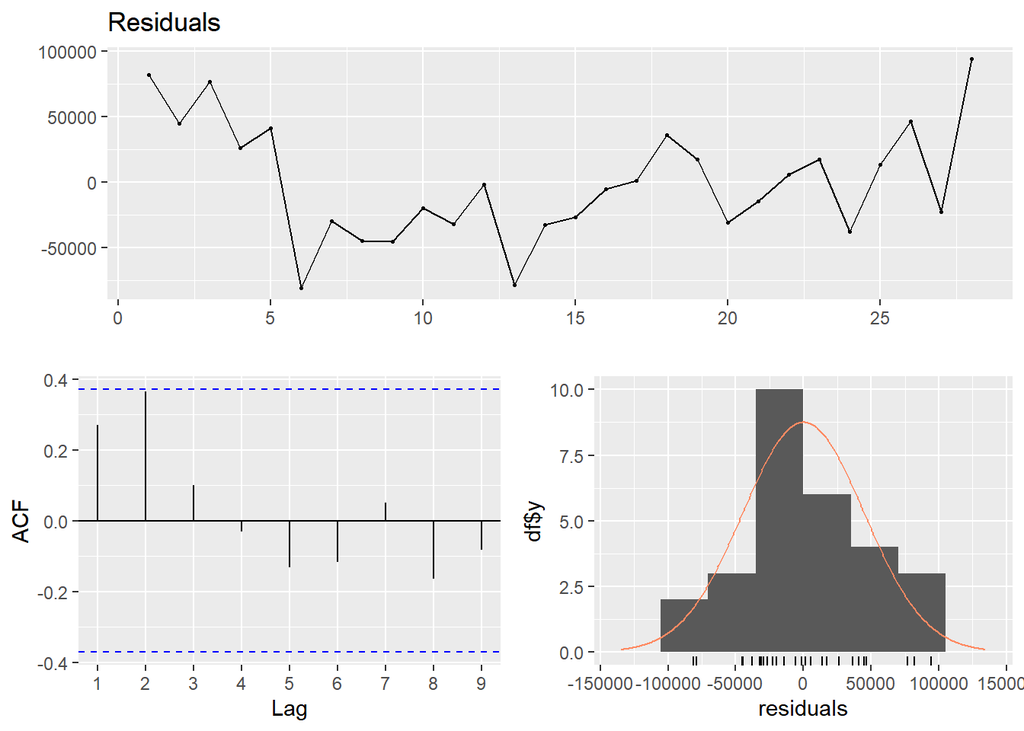

```r
checkresiduals(modelseason$residuals)
```

As can be seen at the table NUGV,NLPG, GNPA and PG has strong correlations with the UGS.

To see the difference after adding the Trend variable on the data, Trend variable is added as a series from 1 to 32 and named as ‘T’. Then, the data is modeled by only considering the Trend variable.

```r
T=seq(1,32,by=1)
data=cbind(data,T)
modeltrend =lm(UGS~T,data=data)
summary(modeltrend)
```

```
##
## Call:
## lm(formula = UGS ~ T, data = data)
##
## Residuals:
##     Min      1Q  Median      3Q     Max
## -199945  -73550  -21904   71224  237369
##
## Coefficients:
##             Estimate Std. Error t value Pr(>|t|)
## (Intercept)  1170777      43293  27.043  < 2e-16 ***
## T             -12660       2608  -4.854 4.95e-05 ***
## ---
## Signif. codes:  0 '***' 0.001 '**' 0.01 '*' 0.05 '.' 0.1 ' ' 1
##
## Residual standard error: 111500 on 26 degrees of freedom
##   (4 observations deleted due to missingness)
## Multiple R-squared:  0.4754, Adjusted R-squared:  0.4552
## F-statistic: 23.56 on 1 and 26 DF,  p-value: 4.945e-05
```

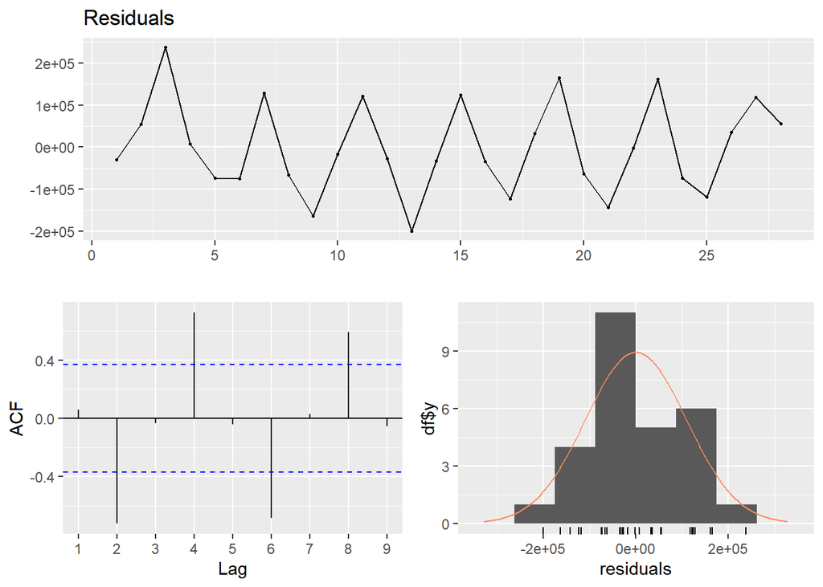

```r
checkresiduals(modeltrend$residuals)
```

Trend predictor has a very small p-value. This can be a sign that it is a good predictor. Seasonality can be observed from the residuals (de-trended UGS). Also, it can be observed at ACF plot, because at the multiples of 4, the data has significant positive correlation.

After the model which only consists of Trend, the season variable is added to the model and another model is created.

```r
modeltrendseason =lm(UGS~Quarter+T+as.factor(Q),data=data)
summary(modeltrendseason)
```

```
##
## Call:
## lm(formula = UGS ~ Quarter + T + as.factor(Q), data = data)
##
## Residuals:
##    Min     1Q Median     3Q    Max
## -81951 -28555   3107  22372  97244
##
## Coefficients:
##                 Estimate Std. Error t value Pr(>|t|)
## (Intercept)   -237307439  381659728  -0.622  0.54048
## Quarter            21937      35124   0.625  0.53869
## T               -2016499    3207083  -0.629  0.53598
## as.factor(Q)2     143959      44532   3.233  0.00383 **
## as.factor(Q)3     302802      53677   5.641 1.13e-05 ***
## as.factor(Q)4     109053      34747   3.139  0.00477 **
## ---
## Signif. codes:  0 '***' 0.001 '**' 0.01 '*' 0.05 '.' 0.1 ' ' 1
##
## Residual standard error: 49230 on 22 degrees of freedom
##   (4 observations deleted due to missingness)
## Multiple R-squared:  0.9134, Adjusted R-squared:  0.8938
## F-statistic: 46.44 on 5 and 22 DF,  p-value: 5.814e-11
```

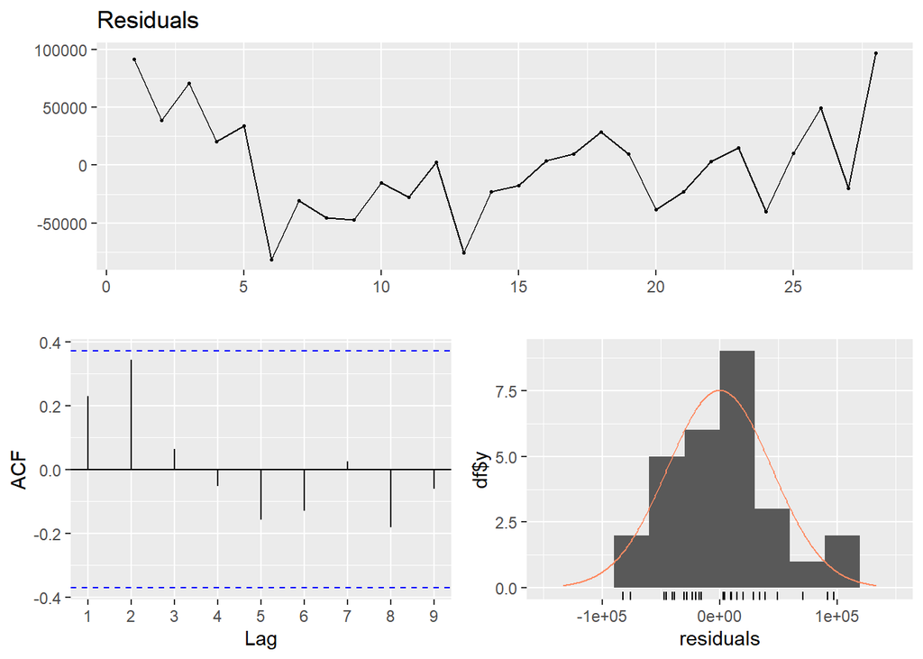

```r
checkresiduals(modeltrendseason$residuals)
```

The variables which have big correlations are added.

```r
modelall =lm(UGS~Q+NLPG+NUGV+PG+PU+GNPA+NDGV+as.factor(Q),data[1:28,])
summary(modelall)
```

```
##
## Call:
## lm(formula = UGS ~ Q + NLPG + NUGV + PG + PU + GNPA + NDGV +
##     as.factor(Q), data = data[1:28, ])
##
## Residuals:
##    Min     1Q Median     3Q    Max
## -81024 -34083  -7464  31944 114565
##
## Coefficients: (1 not defined because of singularities)
##                 Estimate Std. Error t value Pr(>|t|)
## (Intercept)    2.533e+06  4.562e+05   5.553 2.85e-05 ***
## Q              2.548e+04  2.489e+04   1.024  0.31952
## NLPG           1.056e-02  1.202e-01   0.088  0.93092
## NUGV          -2.795e-01  1.142e-01  -2.448  0.02485 *
## PG            -3.443e+02  1.921e+03  -0.179  0.85975
## PU            -3.780e+02  1.547e+03  -0.244  0.80967
## GNPA           1.195e-02  4.988e-02   0.240  0.81339
## NDGV           2.161e-02  1.737e-02   1.244  0.22942
## as.factor(Q)2  9.061e+04  3.099e+04   2.924  0.00906 **
## as.factor(Q)3  1.707e+05  2.445e+05   0.698  0.49399
## as.factor(Q)4         NA         NA      NA       NA
## ---
## Signif. codes:  0 '***' 0.001 '**' 0.01 '*' 0.05 '.' 0.1 ' ' 1
##
## Residual standard error: 58500 on 18 degrees of freedom
## Multiple R-squared:    0.9,  Adjusted R-squared:   0.85
## F-statistic:    18 on 9 and 18 DF,  p-value: 2.913e-07
```

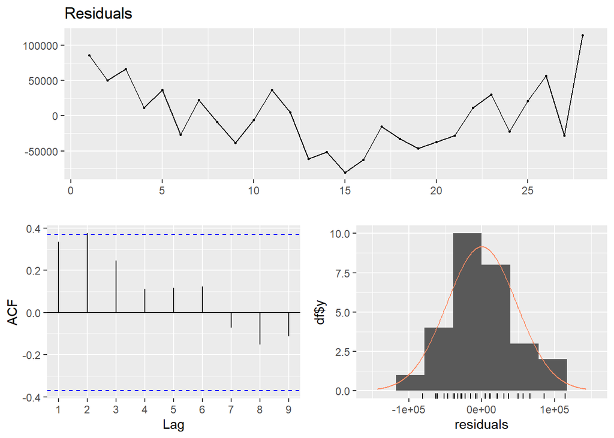

```r
checkresiduals(modelall$residuals)
```

P- value is bigger than the previous with this variables.

After that, only the biggest correlated with UGS, which is NUGV is used.

```r
modelNUGV=lm(UGS~NUGV+as.factor(Q),data=data)
summary(modelNUGV)
```

```
##
## Call:
## lm(formula = UGS ~ NUGV + as.factor(Q), data = data)
##
## Residuals:
##    Min     1Q Median     3Q    Max
## -90511 -36573 -15664  36487 125523
##
## Coefficients:
##                 Estimate Std. Error t value Pr(>|t|)
## (Intercept)    2.699e+06  1.991e+05  13.552 1.88e-12 ***
## NUGV          -3.536e-01  3.857e-02  -9.167 3.84e-09 ***
## as.factor(Q)2  1.238e+05  3.192e+04   3.878 0.000762 ***
## as.factor(Q)3  2.790e+05  3.207e+04   8.698 9.91e-09 ***
## as.factor(Q)4  1.077e+05  3.240e+04   3.323 0.002962 **
## ---
## Signif. codes:  0 '***' 0.001 '**' 0.01 '*' 0.05 '.' 0.1 ' ' 1
##
## Residual standard error: 59640 on 23 degrees of freedom
##   (4 observations deleted due to missingness)
## Multiple R-squared:  0.8672, Adjusted R-squared:  0.8441
## F-statistic: 37.54 on 4 and 23 DF,  p-value: 9.068e-10
```

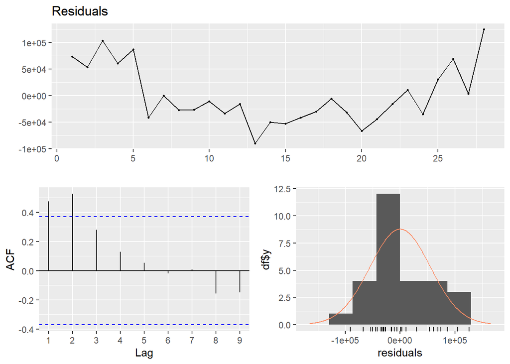

```r
checkresiduals(modelNUGV$residuals)
```

The P-value is even better at this point.

```r
modell =lm(UGS~as.factor(Q)+NLPG+NUGV+PU+NDGV,data=data)
summary(modell)
```

```
##
## Call:
## lm(formula = UGS ~ as.factor(Q) + NLPG + NUGV + PU + NDGV, data = data)
##
## Residuals:
##    Min     1Q Median     3Q    Max
## -79284 -35703  -7507  32813 114893
##
## Coefficients:
##                 Estimate Std. Error t value Pr(>|t|)
## (Intercept)    2.620e+06  3.912e+05   6.697 1.62e-06 ***
## as.factor(Q)2  1.249e+05  3.066e+04   4.073 0.000593 ***
## as.factor(Q)3  2.910e+05  3.062e+04   9.504 7.39e-09 ***
## as.factor(Q)4  9.257e+04  3.129e+04   2.958 0.007777 **
## NLPG           1.164e-02  1.025e-01   0.114 0.910730
## NUGV          -2.850e-01  1.067e-01  -2.671 0.014673 *
## PU            -6.927e+02  3.101e+02  -2.234 0.037089 *
## NDGV           2.265e-02  1.598e-02   1.418 0.171714
## ---
## Signif. codes:  0 '***' 0.001 '**' 0.01 '*' 0.05 '.' 0.1 ' ' 1
##
## Residual standard error: 55620 on 20 degrees of freedom
##   (4 observations deleted due to missingness)
## Multiple R-squared:  0.8996, Adjusted R-squared:  0.8644
## F-statistic: 25.59 on 7 and 20 DF,  p-value: 1.166e-08
```

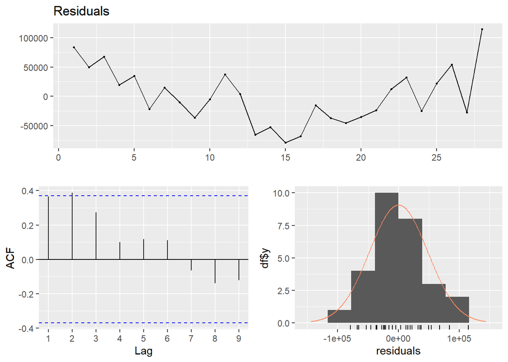

```r
checkresiduals(modell$residuals)
```

For this model,one of those independent variables from previous model is added which helped with the model. However, the issues with residuals persisted.

```r
data$NUGVlag1=lag(data$NUGV,1)
modellag=lm(UGS~as.factor(Q)+NDGV+NUGVlag1+NUGV+PU,data=data)
summary(modellag)
```

```
##
## Call:
## lm(formula = UGS ~ as.factor(Q) + NDGV + NUGVlag1 + NUGV + PU,
##     data = data)
##
## Residuals:
##    Min     1Q Median     3Q    Max
## -63469 -30307   -281  25348  98655
##
## Coefficients:
##                 Estimate Std. Error t value Pr(>|t|)
## (Intercept)    2.498e+06  1.744e+05  14.325 1.23e-11 ***
## as.factor(Q)2  1.253e+05  2.663e+04   4.703 0.000155 ***
## as.factor(Q)3  2.841e+05  2.665e+04  10.661 1.86e-09 ***
## as.factor(Q)4  7.747e+04  2.744e+04   2.824 0.010846 *
## NDGV           9.404e-03  1.321e-02   0.712 0.485067
## NUGVlag1      -9.074e-01  3.332e-01  -2.723 0.013492 *
## NUGV           6.557e-01  3.288e-01   1.994 0.060678 .
## PU            -7.656e+02  2.524e+02  -3.033 0.006837 **
## ---
## Signif. codes:  0 '***' 0.001 '**' 0.01 '*' 0.05 '.' 0.1 ' ' 1
##
## Residual standard error: 44130 on 19 degrees of freedom
##   (5 observations deleted due to missingness)
## Multiple R-squared:  0.9378, Adjusted R-squared:  0.9149
## F-statistic: 40.95 on 7 and 19 DF,  p-value: 3.803e-10
```

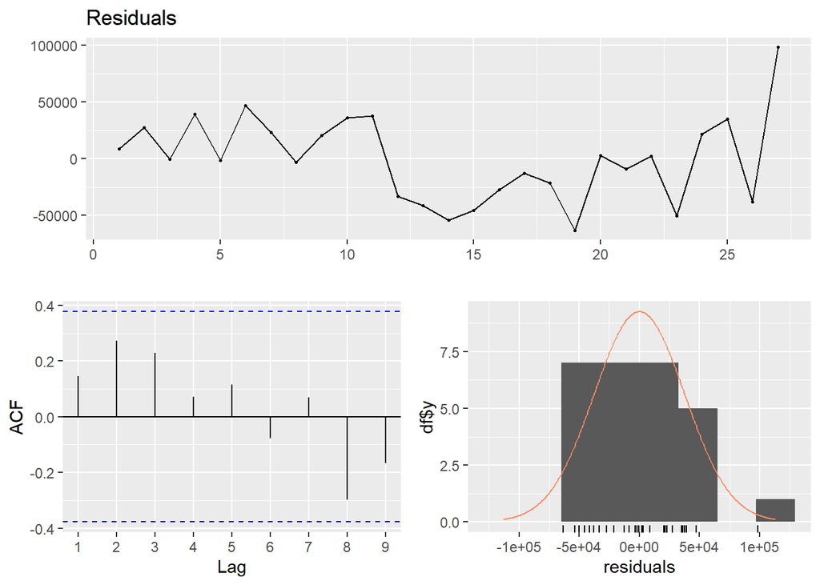

```r
checkresiduals(modellag$residuals)
```

Lastly, the lag 1 variable of the UGS itself is added which can be convincing regarding the model’s being good enough.

```r
data$UGSlag1=lag(data$UGS,1)
modellag2 =lm(UGS~as.factor(Q)+NDGV+UGSlag1+NUGV+PU,data=data)
summary(modellag2)
```

```
##
## Call:
## lm(formula = UGS ~ as.factor(Q) + NDGV + UGSlag1 + NUGV + PU,
##     data = data)
##
## Residuals:
##    Min     1Q Median     3Q    Max
## -71288 -31594    578  24264  93748
##
## Coefficients:
##                 Estimate Std. Error t value Pr(>|t|)
## (Intercept)    1.121e+06  5.220e+05   2.148   0.0448 *
## as.factor(Q)2  1.798e+05  2.930e+04   6.138 6.70e-06 ***
## as.factor(Q)3  2.819e+05  2.731e+04  10.323 3.15e-09 ***
## as.factor(Q)4  1.595e+04  4.294e+04   0.371   0.7144
## NDGV           9.946e-03  1.332e-02   0.747   0.4645
## UGSlag1        4.585e-01  1.752e-01   2.617   0.0169 *
## NUGV          -8.518e-02  7.353e-02  -1.159   0.2610
## PU            -5.848e+02  2.695e+02  -2.170   0.0429 *
## ---
## Signif. codes:  0 '***' 0.001 '**' 0.01 '*' 0.05 '.' 0.1 ' ' 1
##
## Residual standard error: 44610 on 19 degrees of freedom
##   (5 observations deleted due to missingness)
## Multiple R-squared:  0.9365, Adjusted R-squared:  0.9131
## F-statistic: 40.02 on 7 and 19 DF,  p-value: 4.655e-10
```

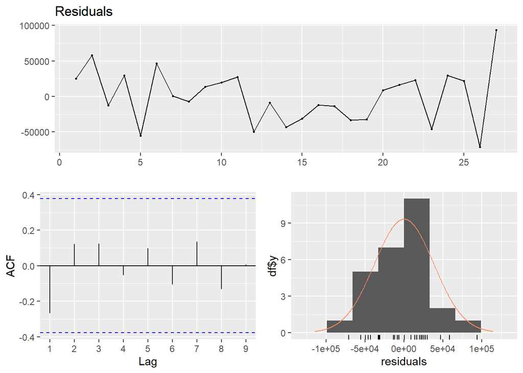

```r
checkresiduals(modellag2$residuals)
```

```r
mean = mean(modellag2$residuals)
paste("Mean of the residuals:",mean)
```

```
## [1] "Mean of the residuals: 8.75809712818375e-13"
```

```r
model= modellag2
```

## 4) Forecasting With Regression

Before moving on with forecasting, what the model predicts for the quarters we already have the data on is shown. Thus, predicted UGS values with the UGS data is plotted in the same graph. As can be seen below, model works fairly well.

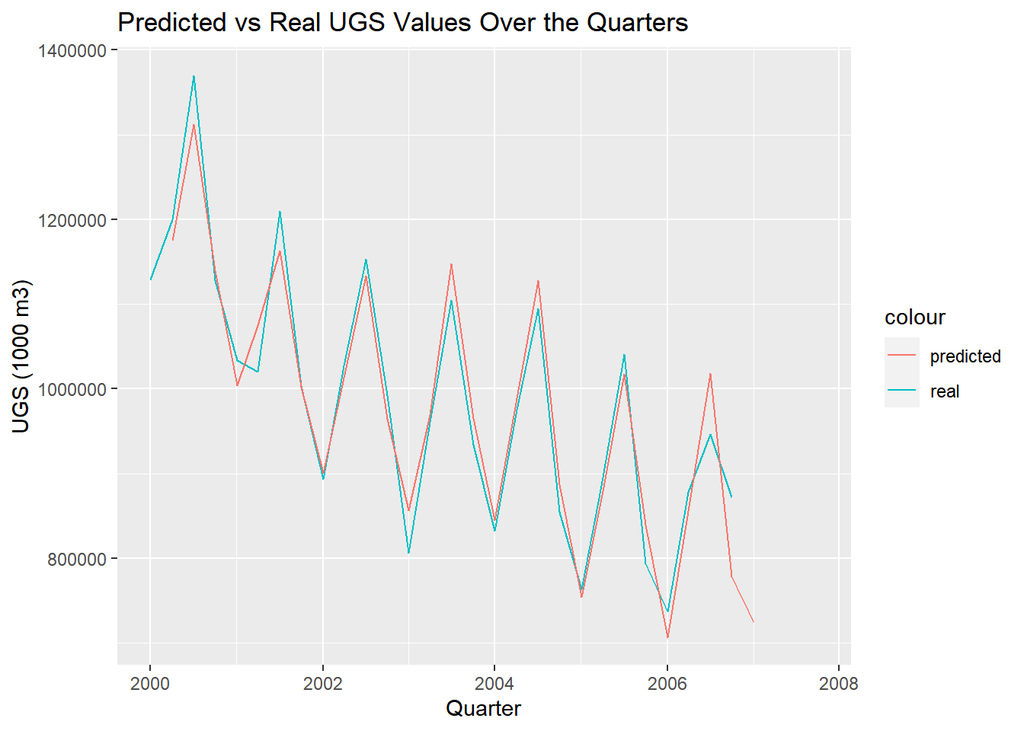

```r
tmp=copy(data)
tmp$actual=data$UGS
tmp$predicted=predict(model,tmp)
ggplot(tmp ,aes(x=Quarter))+
  geom_line(aes(y=actual,color='real')) +
  geom_line(aes(y=predicted,color='predicted'))+
  labs(title = "Predicted vs Real UGS Values Over the Quarters",y="UGS (1000 m3)" )
```

```r
set2007= data[29:32,c("Q","NDGV","UGSlag1","NUGV","PU")]
prediction = c(0,0,0,0)
for(i in 1:4) {
  prediction[i] = predict(model,newdata = set2007[i,])
  if(i<4){set2007[i+1,"UGSlag1"] = prediction[i] }
}
prediction
```

```
## [1] 724629.7 832044.2 978733.5 774277.1
```

At the end, 2007 UGS values for each quarter are forecasted. Since the model needs UGSlag1 data, predictions of the previous quarter for quarters 2,3 & 4 are used.